# The number of close people: friends, neighbours or co-workers

# 1 Description of DataSchema variable

The description of harmonised variable is the following:

- Short name: `clspeop`
- Variable label: `The number of close people: friends, neighbours or co-workers`
- Domain: `Social environment`
- Value type: `continuous`
- Category missings:

| **Code** | **Category Label** |
| --- | --- |
| 991 | CAPI/interviewer error |
| 992 | Impute |
| 993 | Disable to measure |
| 994 | Not attempt/not done |
| 995 | Does not answer |
| 996 | Not applicable |
| 997 | Refuse |
| 998 | Do not know |
| 999 | Missing |

# 2 Data process

## 2.1 England

### 2.1.1 Wave 1

#### 2.1.1.1 Study-specific variable description

The study-specific variable elected to be harmonised is:

- Name: `scfrdm`
- Label: `how many of your friends would you say you have a close relationship`
- Missings:
  - `-9.0 = Not answered`
  - `-1.0 = Item not applicable`
- Description:

SCFRDM

| Sample size | Missing values |
| --- | --- |
| 12099 | 0 |

Summary

| Min. | 1st Qu. | Median | Mean | 3rd Qu. | Max. |
| --- | --- | --- | --- | --- | --- |
| -9 | 0 | 2 | 1.949 | 4 | 98 |

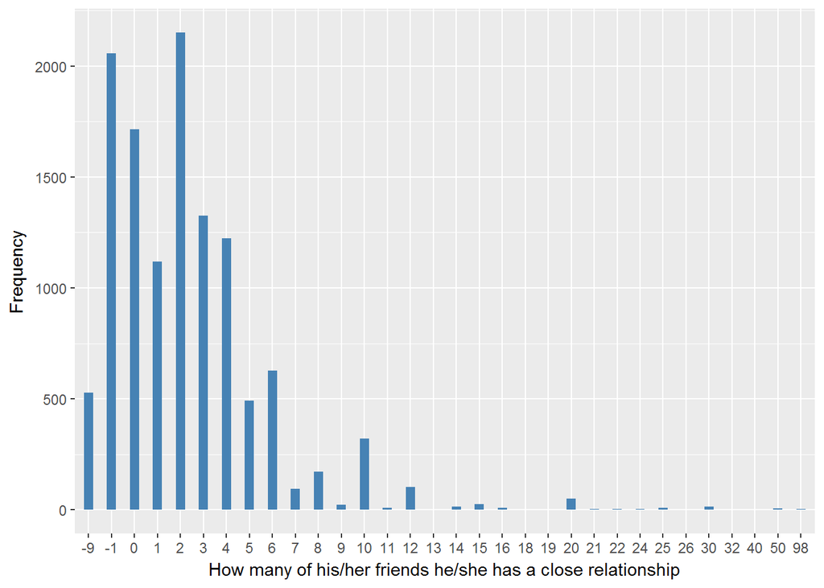

#### 2.1.1.2 Harmonisation algorithm

To compute the harmonize variable from the study-specific variable it has to be recoded as follows:

- `-1 Item not applicable into 996`
- `-9 Not answered into 995`
- `98 or NA into 999`
- `other values into themselves`

**R script:**

```r
ELSA_ds_w1 <- tibble(id = ELSA_w1_clspeop$id)
ELSA_ds_w1$clspeop <- car::recode(as.vector(ELSA_w1_clspeop$scfrdm), "-1='996'; -9='995'; 98='999'; NA='999'")
ELSA_ds_w1$clspeop <- labelled(ELSA_ds_w1$clspeop, labels = c(`lack of close people` = 0,
    Missing = 999, `Do not know` = 998, Refuse = 997, `Not applicable` = 996,
    `Don't answer` = 995, `Not attempt/not done/not yet recorded` = 994, `Disable to measure` = 993,
    Impute = 992, `CAPI/interviewer error` = 991))
```

#### 2.1.1.3 Statistical description of the new harmonised variable

| Sample size | Missing values |
| --- | --- |
| 12099 | 2587 |

Values

|  | No-missings | 991 | 992 | 993 | 994 | 995 | 996 | 997 | 998 | 999 | NA |
| --- | --- | --- | --- | --- | --- | --- | --- | --- | --- | --- | --- |
| Frequency | 9512.00 | 0 | 0 | 0 | 0 | 527.00 | 2058.00 | 0 | 0 | 2.00 | 0 |
| Percentage | 78.62 | 0 | 0 | 0 | 0 | 4.36 | 17.01 | 0 | 0 | 0.02 | 0 |

Summary

| Min. | 1st Qu. | Median | Mean | 3rd Qu. | Max. |
| --- | --- | --- | --- | --- | --- |
| 0 | 1 | 2 | 3.174 | 4 | 50 |

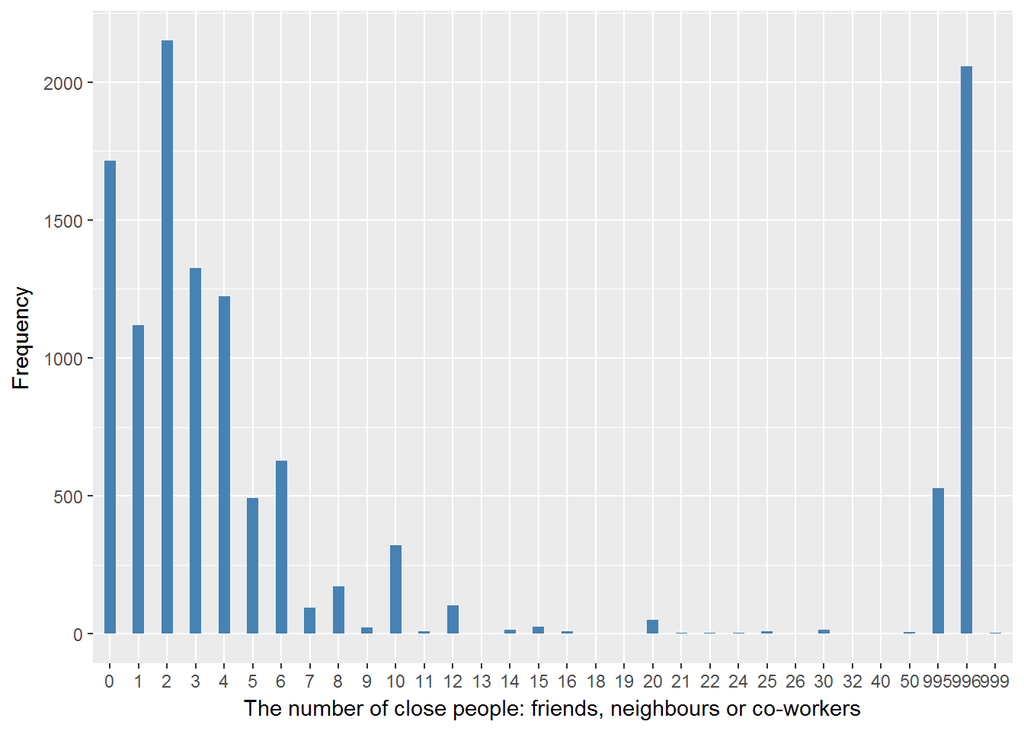

#### 2.1.1.4 Validation

|  | 0 | 1 | 2 | 3 | 4 | 5 | 6 | 7 | 8 | 9 | 10 | 11 | 12 | 13 | 14 | 15 | 16 | 18 | 19 | 20 | 21 | 22 | 24 | 25 | 26 | 30 | 32 | 40 | 50 | … |
| --- | --- | --- | --- | --- | --- | --- | --- | --- | --- | --- | --- | --- | --- | --- | --- | --- | --- | --- | --- | --- | --- | --- | --- | --- | --- | --- | --- | --- | --- | --- |
| BeforeH | 1714 | 1119 | 2151 | 1327 | 1224 | 492 | 626 | 93 | 173 | 23 | 320 | 9 | 102 | 1 | 15 | 26 | 8 | 1 | 1 | 49 | 2 | 2 | 4 | 8 | 1 | 14 | 1 | 1 | 5 | … |
| AfterH | 1714 | 1119 | 2151 | 1327 | 1224 | 492 | 626 | 93 | 173 | 23 | 320 | 9 | 102 | 1 | 15 | 26 | 8 | 1 | 1 | 49 | 2 | 2 | 4 | 8 | 1 | 14 | 1 | 1 | 5 | … |

### 2.1.2 Wave 2

#### 2.1.2.1 Study-specific variable description

The study-specific variable elected to be harmonised is:

- Name: `scfrdm`
- Label: `how many of your friends would you say you have a close relationship`
- Missings:
  - `-9.0 = Not answered`
  - `-1.0 = Item not applicable`
- Description:

SCFRDM

| Sample size | Missing values |
| --- | --- |
| 9432 | 0 |

Summary

| Min. | 1st Qu. | Median | Mean | 3rd Qu. | Max. |
| --- | --- | --- | --- | --- | --- |
| -9 | 0 | 2 | 2.31 | 4 | 98 |

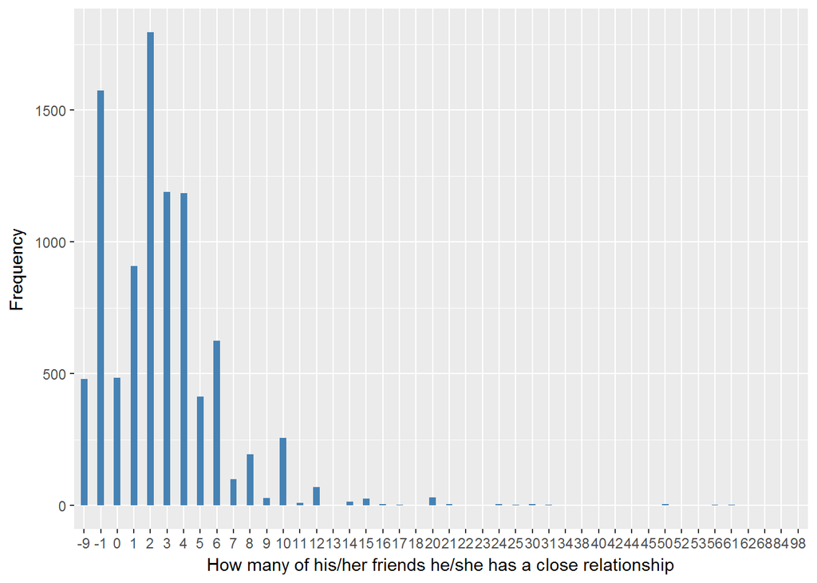

#### 2.1.2.2 Harmonisation algorithm

To recode the harmonize variable from the study-specific variable it has to be recoded as follows:

**R script:**

```r
ELSA_ds_w2 <- tibble(id = ELSA_w2_clspeop$id)
ELSA_ds_w2$clspeop <- car::recode(as.vector(ELSA_w2_clspeop$scfrdm), "-1='996'; -9='995'; 98='999'; NA='999'")
ELSA_ds_w2$clspeop <- labelled(ELSA_ds_w2$clspeop, labels = c(`lack of close people` = 0,
    Missing = 999, `Do not know` = 998, Refuse = 997, `Not applicable` = 996,
    `Don't answer` = 995, `Not attempt/not done/not yet recorded` = 994, `Disable to measure` = 993,
    Impute = 992, `CAPI/interviewer error` = 991))
### one wird value of 98 -> recode into 999
```

#### 2.1.2.3 Statistical description of the new harmonised variable

| Sample size | Missing values |
| --- | --- |
| 9432 | 2055 |

Values

|  | No-missings | 991 | 992 | 993 | 994 | 995 | 996 | 997 | 998 | 999 | NA |
| --- | --- | --- | --- | --- | --- | --- | --- | --- | --- | --- | --- |
| Frequency | 7377.00 | 0 | 0 | 0 | 0 | 479.00 | 1575.0 | 0 | 0 | 1.00 | 0 |
| Percentage | 78.21 | 0 | 0 | 0 | 0 | 5.08 | 16.7 | 0 | 0 | 0.01 | 0 |

Summary

| Min. | 1st Qu. | Median | Mean | 3rd Qu. | Max. |
| --- | --- | --- | --- | --- | --- |
| 0 | 2 | 3 | 3.738 | 4 | 84 |

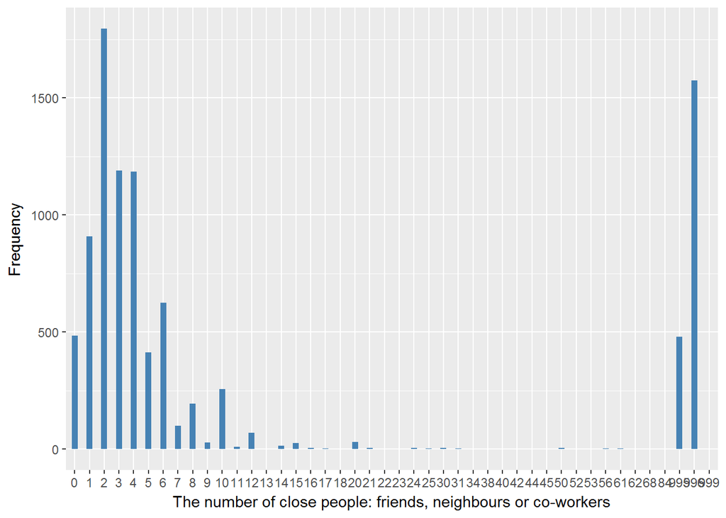

#### 2.1.2.4 Validation

|  | 0 | 1 | 2 | 3 | 4 | 5 | 6 | 7 | 8 | 9 | 10 | 11 | 12 | 13 | 14 | 15 | 16 | 17 | 18 | 20 | 21 | 22 | 23 | 24 | 25 | 30 | 31 | 34 | 38 | … |
| --- | --- | --- | --- | --- | --- | --- | --- | --- | --- | --- | --- | --- | --- | --- | --- | --- | --- | --- | --- | --- | --- | --- | --- | --- | --- | --- | --- | --- | --- | --- |
| BeforeH | 484 | 908 | 1795 | 1190 | 1184 | 413 | 625 | 100 | 195 | 28 | 255 | 10 | 69 | 1 | 14 | 25 | 5 | 3 | 1 | 31 | 4 | 1 | 1 | 5 | 3 | 4 | 2 | 1 | 1 | … |
| AfterH | 484 | 908 | 1795 | 1190 | 1184 | 413 | 625 | 100 | 195 | 28 | 255 | 10 | 69 | 1 | 14 | 25 | 5 | 3 | 1 | 31 | 4 | 1 | 1 | 5 | 3 | 4 | 2 | 1 | 1 | … |

### 2.1.3 Wave 3

#### 2.1.3.1 Study-specific variable description

The study-specific variable elected to be harmonised is:

- Name: `scfrdm`
- Label: `how many of your friends would you say you have a close relationship`
- Missings:
  - `-1.0 = Item not applicable`
  - `-8.0 = Don't know`
  - `-9.0 = Not answered`
- Description:

SCFRDM

| Sample size | Missing values |
| --- | --- |
| 9771 | 0 |

Summary

| Min. | 1st Qu. | Median | Mean | 3rd Qu. | Max. |
| --- | --- | --- | --- | --- | --- |
| -9 | -1 | 2 | 2.739 | 4 | 90 |

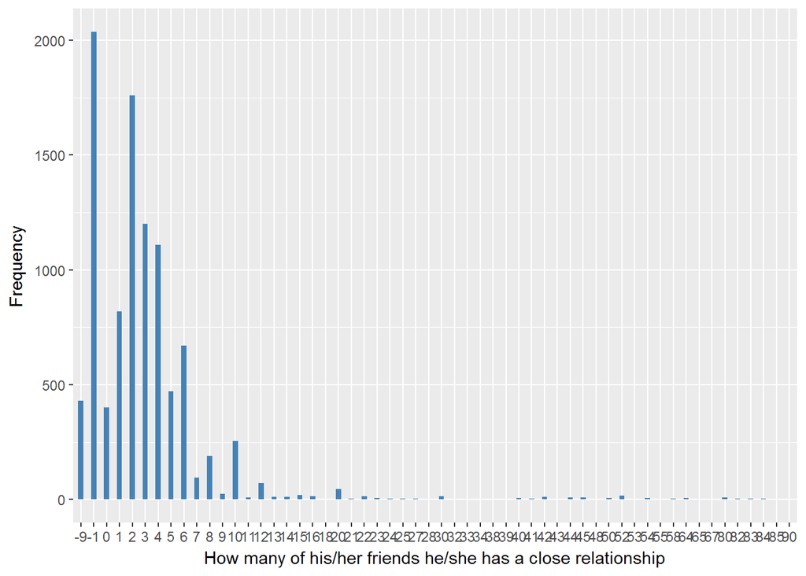

#### 2.1.3.2 Harmonisation algorithm

To recode the harmonize variable from the study-specific variable it has to be recoded as follows:

- `-1 Item not applicable into 996`
- `-8 Don't Know into 998`
- `-9 Not answered into 995`
- `NA into 999`
- `other values into themselves`

**R script:**

```r
ELSA_ds_w3 <- tibble(id = ELSA_w3_clspeop$id)
ELSA_ds_w3$clspeop <- car::recode(as.vector(ELSA_w3_clspeop$scfrdm), "-9='995'; -8='998'; -1='996'; NA='999'")
ELSA_ds_w3$clspeop <- labelled(ELSA_ds_w3$clspeop, labels = c(`lack of close people` = 0,
    Missing = 999, `Do not know` = 998, Refuse = 997, `Not applicable` = 996,
    `Don't answer` = 995, `Not attempt/not done/not yet recorded` = 994, `Disable to measure` = 993,
    Impute = 992, `CAPI/interviewer error` = 991))
```

#### 2.1.3.3 Statistical description of the new harmonised variable

| Sample size | Missing values |
| --- | --- |
| 9771 | 2465 |

Values

|  | No-missings | 991 | 992 | 993 | 994 | 995 | 996 | 997 | 998 | 999 | NA |
| --- | --- | --- | --- | --- | --- | --- | --- | --- | --- | --- | --- |
| Frequency | 7306.00 | 0 | 0 | 0 | 0 | 429.00 | 2036.00 | 0 | 0 | 0 | 0 |
| Percentage | 74.77 | 0 | 0 | 0 | 0 | 4.39 | 20.84 | 0 | 0 | 0 | 0 |

Summary

| Min. | 1st Qu. | Median | Mean | 3rd Qu. | Max. |
| --- | --- | --- | --- | --- | --- |
| 0 | 2 | 3 | 4.47 | 5 | 90 |

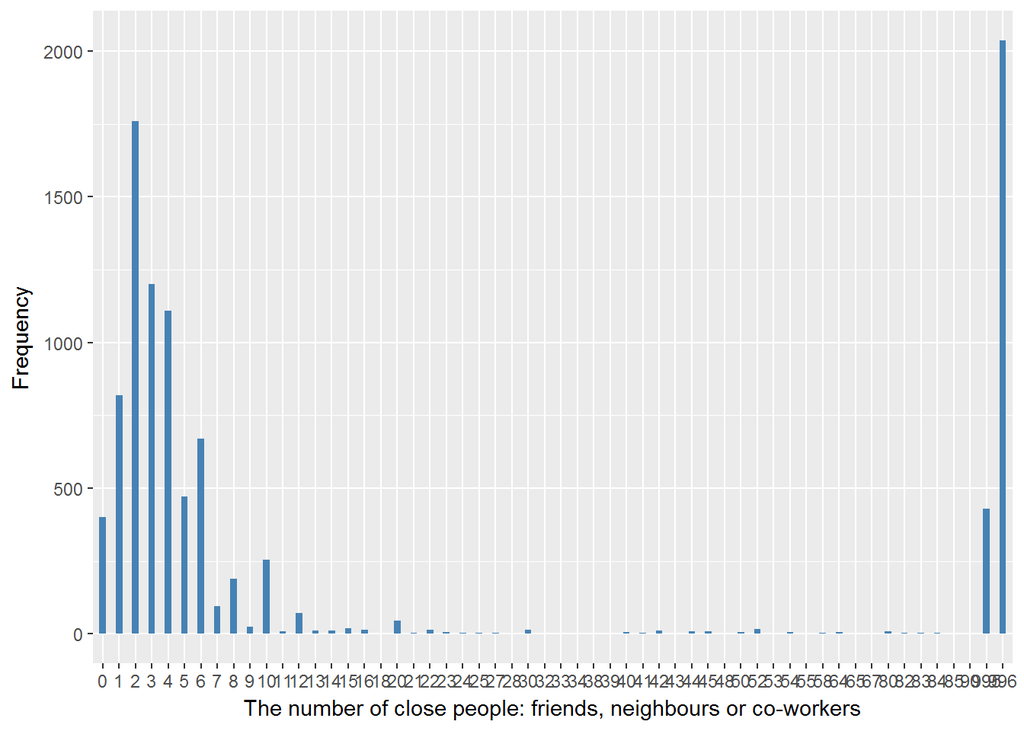

##### 2.1.3.3.1 Validation

|  | 0 | 1 | 2 | 3 | 4 | 5 | 6 | 7 | 8 | 9 | 10 | 11 | 12 | 13 | 14 | 15 | 16 | 18 | 20 | 21 | 22 | 23 | 24 | 25 | 27 | 28 | 30 | 32 | 33 | … |
| --- | --- | --- | --- | --- | --- | --- | --- | --- | --- | --- | --- | --- | --- | --- | --- | --- | --- | --- | --- | --- | --- | --- | --- | --- | --- | --- | --- | --- | --- | --- |
| BeforeH | 400 | 819 | 1760 | 1200 | 1108 | 470 | 669 | 94 | 189 | 24 | 255 | 8 | 71 | 10 | 11 | 18 | 13 | 1 | 44 | 3 | 14 | 6 | 2 | 4 | 2 | 1 | 13 | 1 | 1 | … |
| AfterH | 400 | 819 | 1760 | 1200 | 1108 | 470 | 669 | 94 | 189 | 24 | 255 | 8 | 71 | 10 | 11 | 18 | 13 | 1 | 44 | 3 | 14 | 6 | 2 | 4 | 2 | 1 | 13 | 1 | 1 | … |

### 2.1.4 Wave 4

#### 2.1.4.1 Study-specific variable description

The study-specific variable elected to be harmonised is:

- Name: `scfrdm`
- Label: `how many of your friends would you say you have a close relationship`
- Missings:
  - `-1.0 = Item not applicable`
  - `-8.0 = Don't know`
  - `-9.0 = Not answered`
- Description:

SCFRDM

| Sample size | Missing values |
| --- | --- |
| 11050 | 0 |

Summary

| Min. | 1st Qu. | Median | Mean | 3rd Qu. | Max. |
| --- | --- | --- | --- | --- | --- |
| -9 | 0 | 2 | 2.266 | 4 | 90 |

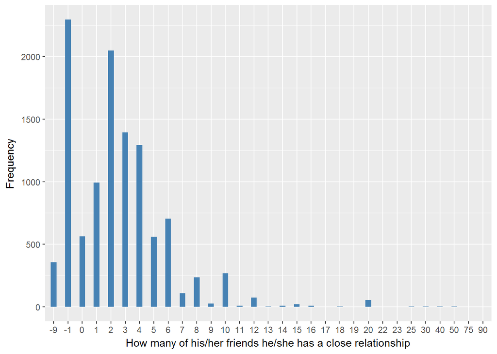

#### 2.1.4.2 Harmonisation algorithm

To recode the harmonize variable from the study-specific variable it has to be recoded as follows:

- `-1 Item not applicable into 996`
- `-8 Don't Know into 998`
- `-9 Not answered into 995`
- `NA into 999`
- `other values into themselves`

**R script:**

```r
ELSA_ds_w4 <- tibble(id = ELSA_w4_clspeop$id)
ELSA_ds_w4$clspeop <- car::recode(as.vector(ELSA_w4_clspeop$scfrdm), "-9='995'; -8='998'; -1='996'; NA='999'")
ELSA_ds_w4$clspeop <- labelled(ELSA_ds_w4$clspeop, labels = c(`lack of close people` = 0,
    Missing = 999, `Do not know` = 998, Refuse = 997, `Not applicable` = 996,
    `Don't answer` = 995, `Not attempt/not done/not yet recorded` = 994, `Disable to measure` = 993,
    Impute = 992, `CAPI/interviewer error` = 991))
```

#### 2.1.4.3 Statistical description of the new harmonised variable

| Sample size | Missing values |
| --- | --- |
| 11050 | 2652 |

Values

|  | No-missings | 991 | 992 | 993 | 994 | 995 | 996 | 997 | 998 | 999 | NA |
| --- | --- | --- | --- | --- | --- | --- | --- | --- | --- | --- | --- |
| Frequency | 8398 | 0 | 0 | 0 | 0 | 358.00 | 2294.00 | 0 | 0 | 0 | 0 |
| Percentage | 76 | 0 | 0 | 0 | 0 | 3.24 | 20.76 | 0 | 0 | 0 | 0 |

Summary

| Min. | 1st Qu. | Median | Mean | 3rd Qu. | Max. |
| --- | --- | --- | --- | --- | --- |
| 0 | 2 | 3 | 3.638 | 5 | 90 |

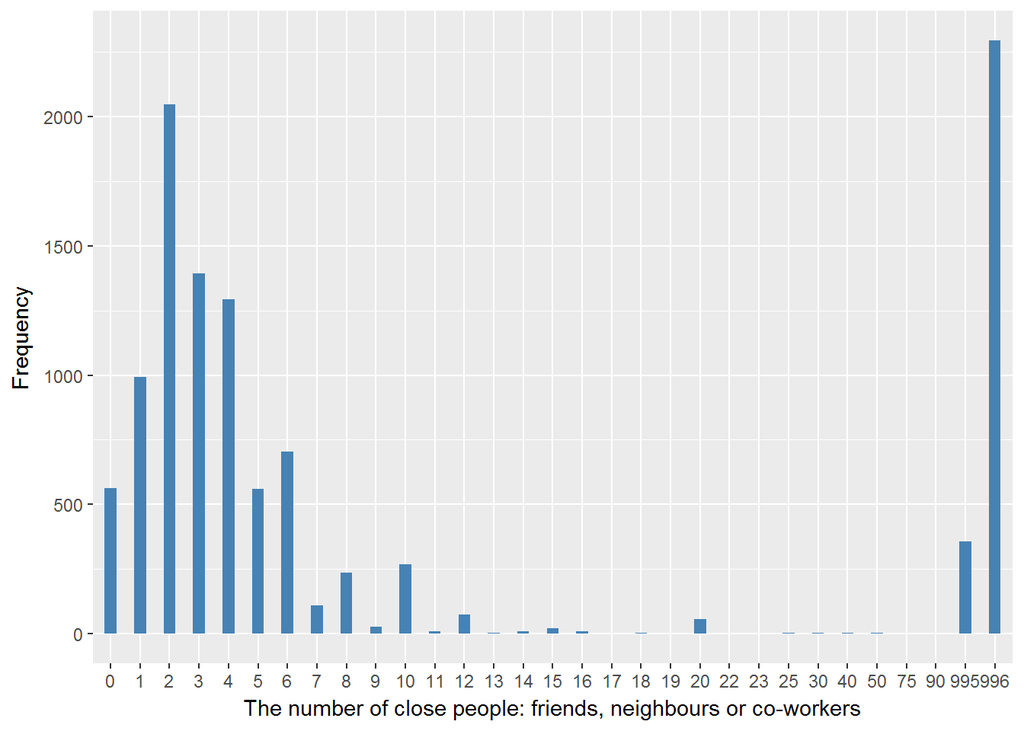

#### 2.1.4.4 Validation

|  | 0 | 1 | 2 | 3 | 4 | 5 | 6 | 7 | 8 | 9 | 10 | 11 | 12 | 13 | 14 | 15 | 16 | 17 | 18 | 19 | 20 | 22 | 23 | 25 | 30 | 40 | 50 | 75 | 90 | … |
| --- | --- | --- | --- | --- | --- | --- | --- | --- | --- | --- | --- | --- | --- | --- | --- | --- | --- | --- | --- | --- | --- | --- | --- | --- | --- | --- | --- | --- | --- | --- |
| BeforeH | 562 | 992 | 2048 | 1392 | 1294 | 560 | 704 | 110 | 236 | 27 | 269 | 10 | 74 | 2 | 10 | 21 | 8 | 1 | 4 | 1 | 56 | 1 | 1 | 4 | 4 | 2 | 3 | 1 | 1 | … |
| AfterH | 562 | 992 | 2048 | 1392 | 1294 | 560 | 704 | 110 | 236 | 27 | 269 | 10 | 74 | 2 | 10 | 21 | 8 | 1 | 4 | 1 | 56 | 1 | 1 | 4 | 4 | 2 | 3 | 1 | 1 | … |

### 2.1.5 Wave 5

#### 2.1.5.1 Study-specific variable description

The study-specific variable elected to be harmonised is:

- Name: `scfrdm`
- Label: `how many of your friends would you say you have a close relationship`
- Missings:
  - `-1.0 = Item not applicable`
  - `-2.0 = Schedule Not Applicable`
  - `-8.0 = Don't know`
  - `-9.0 = Not answered`
- Description:

SCFRDM

| Sample size | Missing values |
| --- | --- |
| 10274 | 0 |

Summary

| Min. | 1st Qu. | Median | Mean | 3rd Qu. | Max. |
| --- | --- | --- | --- | --- | --- |
| -9 | 0 | 2 | 1.893 | 4 | 97 |

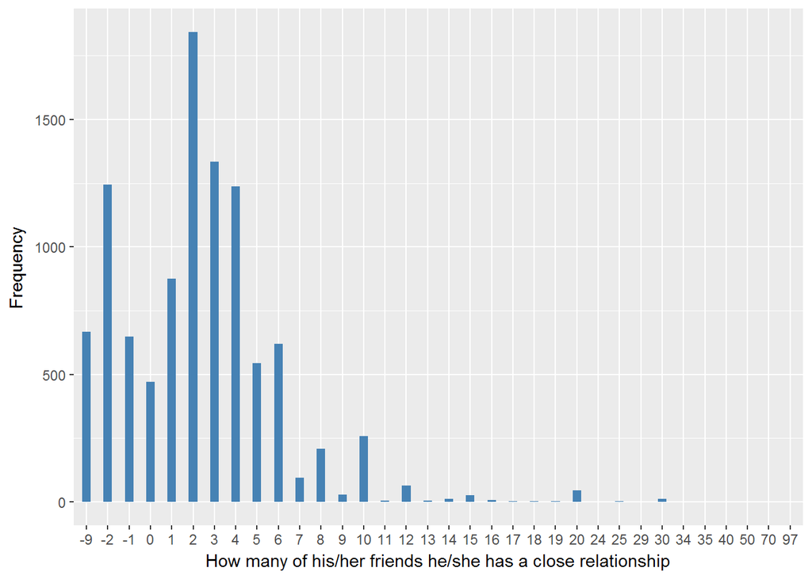

#### 2.1.5.2 Harmonisation algorithm

To recode the harmonize variable from the study-specific variable it has to be recoded as follows:

- `-1 Item not applicable into 996`
- `-2 Schedule Not Applicable into 996`
- `-8 Don't Know into 998`
- `-9 Not answered into 995`
- `NA into 999`
- `other values into themselves`

**R script:**

```r
ELSA_ds_w5 <- tibble(id = ELSA_w5_clspeop$id)
ELSA_ds_w5$clspeop <- car::recode(as.vector(ELSA_w5_clspeop$scfrdm), "-9='995'; -8='998'; -2='996'; -1='996'; NA='999'")
ELSA_ds_w5$clspeop <- labelled(ELSA_ds_w5$clspeop, labels = c(`lack of close people` = 0,
    Missing = 999, `Do not know` = 998, Refuse = 997, `Not applicable` = 996,
    `Don't answer` = 995, `Not attempt/not done/not yet recorded` = 994, `Disable to measure` = 993,
    Impute = 992, `CAPI/interviewer error` = 991))
### What about one value 97???
```

#### 2.1.5.3 Statistical description of the new harmonised variable

| Sample size | Missing values |
| --- | --- |
| 10274 | 2560 |

Values

|  | No-missings | 991 | 992 | 993 | 994 | 995 | 996 | 997 | 998 | 999 | NA |
| --- | --- | --- | --- | --- | --- | --- | --- | --- | --- | --- | --- |
| Frequency | 7714.00 | 0 | 0 | 0 | 0 | 668.0 | 1892.00 | 0 | 0 | 0 | 0 |
| Percentage | 75.08 | 0 | 0 | 0 | 0 | 6.5 | 18.42 | 0 | 0 | 0 | 0 |

Summary

| Min. | 1st Qu. | Median | Mean | 3rd Qu. | Max. |
| --- | --- | --- | --- | --- | --- |
| 0 | 2 | 3 | 3.708 | 5 | 97 |

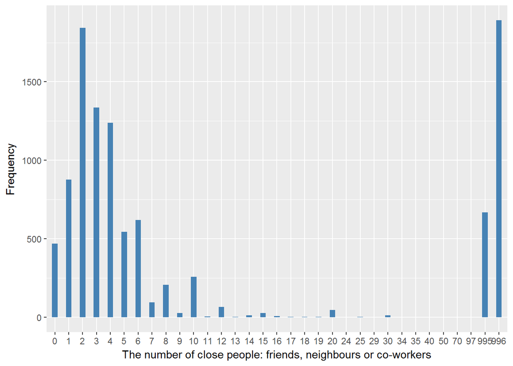

#### 2.1.5.4 Validation

|  | 0 | 1 | 2 | 3 | 4 | 5 | 6 | 7 | 8 | 9 | 10 | 11 | 12 | 13 | 14 | 15 | 16 | 17 | 18 | 19 | 20 | 24 | 25 | 29 | 30 | 34 | 35 | 40 | 50 | … |
| --- | --- | --- | --- | --- | --- | --- | --- | --- | --- | --- | --- | --- | --- | --- | --- | --- | --- | --- | --- | --- | --- | --- | --- | --- | --- | --- | --- | --- | --- | --- |
| BeforeH | 470 | 876 | 1843 | 1335 | 1238 | 545 | 619 | 95 | 208 | 28 | 259 | 6 | 65 | 4 | 13 | 26 | 7 | 2 | 3 | 2 | 46 | 1 | 3 | 1 | 13 | 1 | 1 | 1 | 1 | … |
| AfterH | 470 | 876 | 1843 | 1335 | 1238 | 545 | 619 | 95 | 208 | 28 | 259 | 6 | 65 | 4 | 13 | 26 | 7 | 2 | 3 | 2 | 46 | 1 | 3 | 1 | 13 | 1 | 1 | 1 | 1 | … |

### 2.1.6 Wave 6

#### 2.1.6.1 Study-specific variable description

The study-specific variable elected to be harmonised is:

- Name: `scfrdm`
- Label: `how many of your friends would you say you have a close relationship`
- Missings:
  - `-1.0 = Item not applicable`
  - `-2.0 = Schedule Not Applicable`
  - `-8.0 = Don't know`
  - `-9.0 = Not answered`
- Description:

SCFRDM

| Sample size | Missing values |
| --- | --- |
| 10601 | 0 |

Summary

| Min. | 1st Qu. | Median | Mean | 3rd Qu. | Max. |
| --- | --- | --- | --- | --- | --- |
| -9 | -1 | 2 | 1.912 | 4 | 50 |

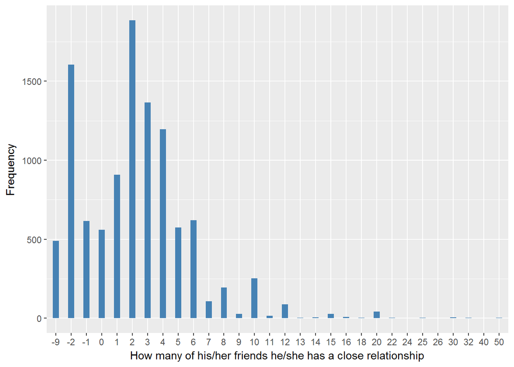

#### 2.1.6.2 Harmonisation algorithm

To recode the harmonize variable from the study-specific variable it has to be recoded as follows:

- `-1 Item not applicable into 996`
- `-2 Schedule Not Applicable into 996`
- `-8 Don't Know into 998`
- `-9 Not answered into 995`
- `NA into 999`
- `other values into themselves`

**R script:**

```r
ELSA_ds_w6 <- tibble(id = ELSA_w6_clspeop$id)
ELSA_ds_w6$clspeop <- car::recode(as.vector(ELSA_w6_clspeop$scfrdm), "-9='995'; -8='998'; -2='996'; -1='996'; NA='999'")
ELSA_ds_w6$clspeop <- labelled(ELSA_ds_w6$clspeop, labels = c(`lack of close people` = 0,
    Missing = 999, `Do not know` = 998, Refuse = 997, `Not applicable` = 996,
    `Don't answer` = 995, `Not attempt/not done/not yet recorded` = 994, `Disable to measure` = 993,
    Impute = 992, `CAPI/interviewer error` = 991))
```

#### 2.1.6.3 Statistical description of the new harmonised variable

| Sample size | Missing values |
| --- | --- |
| 10601 | 2707 |

Values

|  | No-missings | 991 | 992 | 993 | 994 | 995 | 996 | 997 | 998 | 999 | NA |
| --- | --- | --- | --- | --- | --- | --- | --- | --- | --- | --- | --- |
| Frequency | 7894.00 | 0 | 0 | 0 | 0 | 489.00 | 2218.00 | 0 | 0 | 0 | 0 |
| Percentage | 74.46 | 0 | 0 | 0 | 0 | 4.61 | 20.92 | 0 | 0 | 0 | 0 |

Summary

| Min. | 1st Qu. | Median | Mean | 3rd Qu. | Max. |
| --- | --- | --- | --- | --- | --- |
| 0 | 2 | 3 | 3.61 | 5 | 50 |

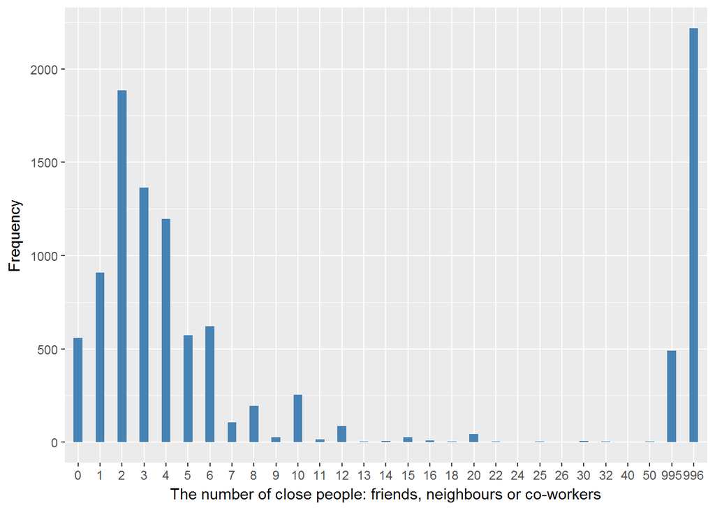

#### 2.1.6.4 Validation

|  | 0 | 1 | 2 | 3 | 4 | 5 | 6 | 7 | 8 | 9 | 10 | 11 | 12 | 13 | 14 | 15 | 16 | 18 | 20 | 22 | 24 | 25 | 26 | 30 | 32 | 40 | 50 | -9->995 | -1,-2->996 |
| --- | --- | --- | --- | --- | --- | --- | --- | --- | --- | --- | --- | --- | --- | --- | --- | --- | --- | --- | --- | --- | --- | --- | --- | --- | --- | --- | --- | --- | --- |
| BeforeH | 559 | 908 | 1885 | 1364 | 1195 | 573 | 621 | 107 | 195 | 27 | 253 | 14 | 87 | 3 | 6 | 26 | 8 | 4 | 42 | 2 | 1 | 3 | 1 | 5 | 2 | 1 | 2 | 489 | 2218 |
| AfterH | 559 | 908 | 1885 | 1364 | 1195 | 573 | 621 | 107 | 195 | 27 | 253 | 14 | 87 | 3 | 6 | 26 | 8 | 4 | 42 | 2 | 1 | 3 | 1 | 5 | 2 | 1 | 2 | 489 | 2218 |

### 2.1.7 Wave 7

#### 2.1.7.1 Study-specific variable description

The study-specific variable elected to be harmonised is:

- Name: `scfrdl`
- Label: `How many friends the respondent has a close relationship with`
- Missings:
  - `-1 = Item not applicable`
  - `-2 = Schedule Not Applicable`
  - `-8 = Don't know`
  - `-9 = Not answered`
- Description:

| Sample size | Missing values |
| --- | --- |
| 9666 | 2896 |

Summary

| Min. | 1st Qu. | Median | Mean | 3rd Qu. | Max. |
| --- | --- | --- | --- | --- | --- |
| 0 | 2 | 3 | 3.727 | 5 | 60 |

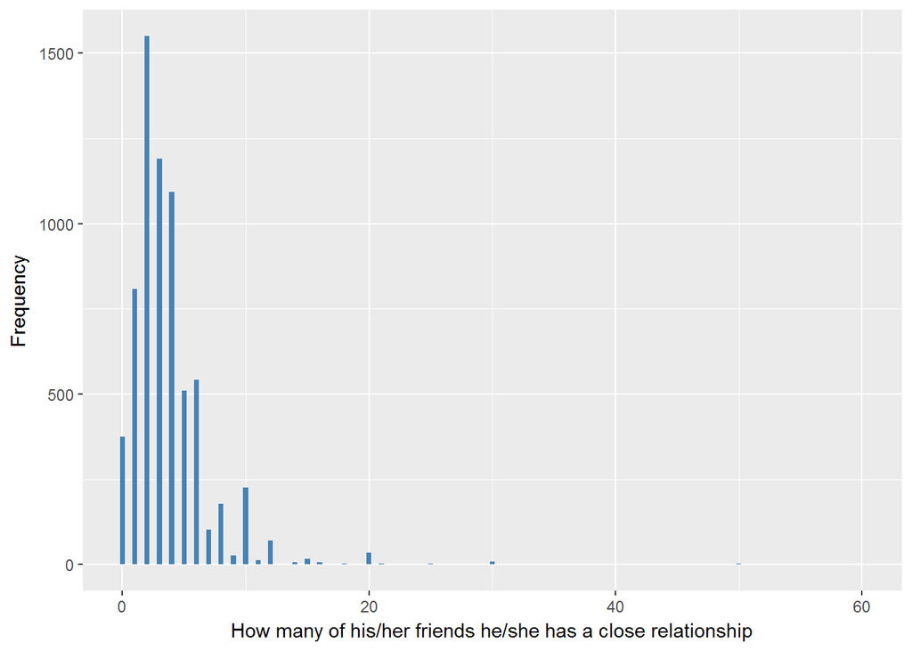

#### 2.1.7.2 Harmonisation algorithm

To recode the harmonize variable from the study-specific variable it has to be recoded as follows:

- `-1 Item not applicable into 996`
- `-2 Schedule Not Applicable into 996`
- `-8 Don't Know into 998`
- `-9 Not answered into 995`
- `NA into 999`
- `other values into themselves`

**R script:**

```r
ELSA_ds_w7 <- tibble(id = ELSA_w7$id)
ELSA_ds_w7$clspeop <- car::recode(as.vector(ELSA_w7$scfrdl), "-9='995'; -8='998'; -2='996'; -1='996'; NA='999'")
ELSA_ds_w7$clspeop <- labelled(ELSA_ds_w7$clspeop, labels = c(`lack of close people` = 0,
    Missing = 999, `Do not know` = 998, Refuse = 997, `Not applicable` = 996,
    `Don't answer` = 995, `Not attempt/not done/not yet recorded` = 994, `Disable to measure` = 993,
    Impute = 992, `CAPI/interviewer error` = 991))
```

#### 2.1.7.3 Statistical description of the new harmonised variable

| Sample size | Missing values |
| --- | --- |
| 9666 | 2896 |

Values

|  | No-missings | 991 | 992 | 993 | 994 | 995 | 996 | 997 | 998 | 999 | NA |
| --- | --- | --- | --- | --- | --- | --- | --- | --- | --- | --- | --- |
| Frequency | 6770.00 | 0 | 0 | 0 | 0 | 850.00 | 2046.00 | 0 | 0 | 0 | 0 |
| Percentage | 70.04 | 0 | 0 | 0 | 0 | 8.79 | 21.17 | 0 | 0 | 0 | 0 |

Summary

| Min. | 1st Qu. | Median | Mean | 3rd Qu. | Max. |
| --- | --- | --- | --- | --- | --- |
| 0 | 2 | 3 | 3.727 | 5 | 60 |

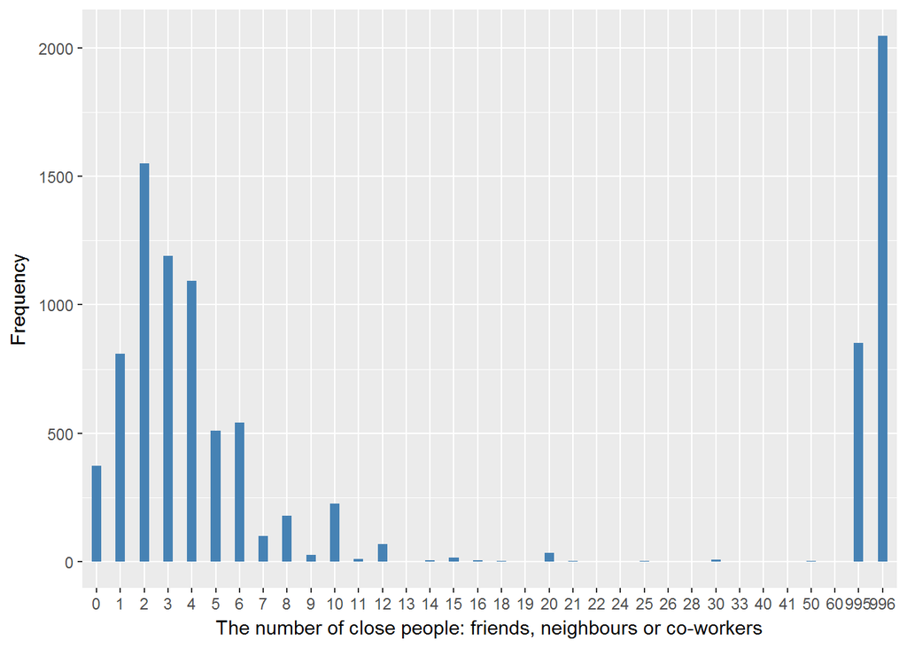

#### 2.1.7.4 Validation

[output not shown]

# 3 Quality estimation